# R Notebook

# Lab Exercises 3 Solutions

## Question 1

We looked at this question last week. Use Monte Carlo simulation to get the same answers as last week to 2 decimal places.

#### (a) A basketball fan watches Michael Jordan and of 100 randomly chosen free throws in 20 games, Jordan makes 89 of them. Given a uniform prior, find the posterior density for the true proportion of successful free throws and a 95% credible interval. Plot this density.

Recall that the posterior is a $Beta(90,12)$ and the answer in R is

```r
qbeta(0.025,90,12)
```

```
## [1] 0.8134799
```

```r
qbeta(0.975,90,12)
```

```
## [1] 0.9370766
```

We need to simulate a $Beta(90,12)$ here. The R command $rbeta(k,a,b)$ Simulates a sample of size k from a Beta(a,b) density. Let’s start with 100 MC sample

```r
thetaj <- rbeta(100,90,12)
quantile(thetaj,c(0.025,0.975))
```

```
##      2.5%     97.5%
## 0.8287956 0.9365911
```

which returns (for example: remember, this is a random sample) $(0.819, 0.938)$, and so even 100 MC samples gives 1-2 decimal places of accuracy. Let’s try 1000 samples:

```r
thetaj <- rbeta(1000,90,12)
quantile(thetaj,c(0.025,0.975))
```

```
##      2.5%     97.5%
## 0.8123496 0.9339616
```

which gives $(0.8200480, 0.9327415)$ again 1-2 decimal accuracy. Now 10000 samples

```r
thetaj <- rbeta(10000,90,12)
quantile(thetaj,c(0.025,0.975))
```

```
##      2.5%     97.5%
## 0.8164167 0.9368444
```

which gives $(0.8144603, 0.9369110)$ and we have 3 decimal places of accuracy. We can plot the histogram of our sample to approximate the true density:

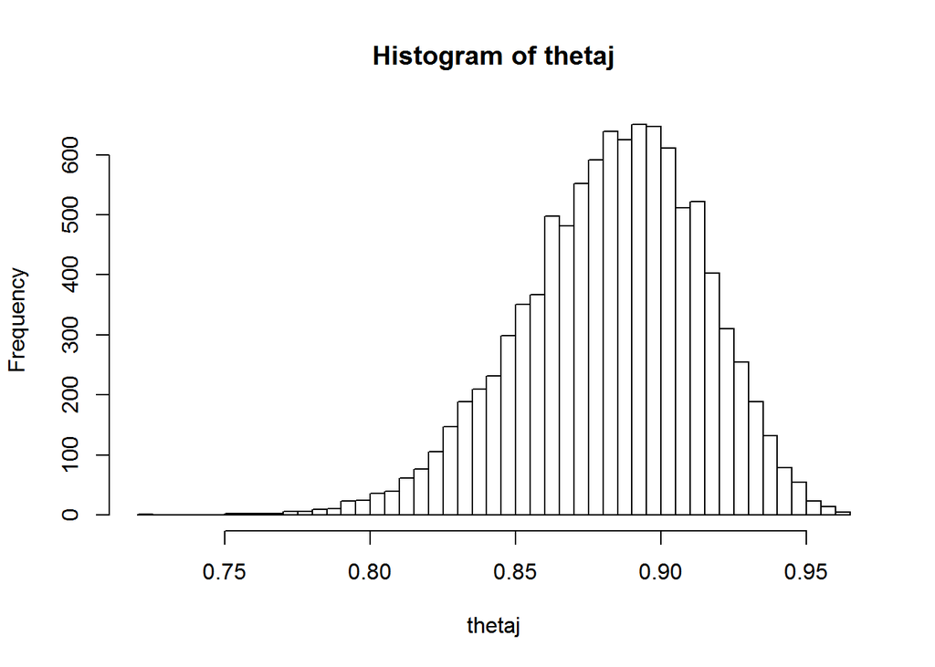

```r
hist(thetaj,50)
```

where 50 is the number of bines in the histogram hist(theta) uses a default number of bins.

R has a density estimator/smoother:

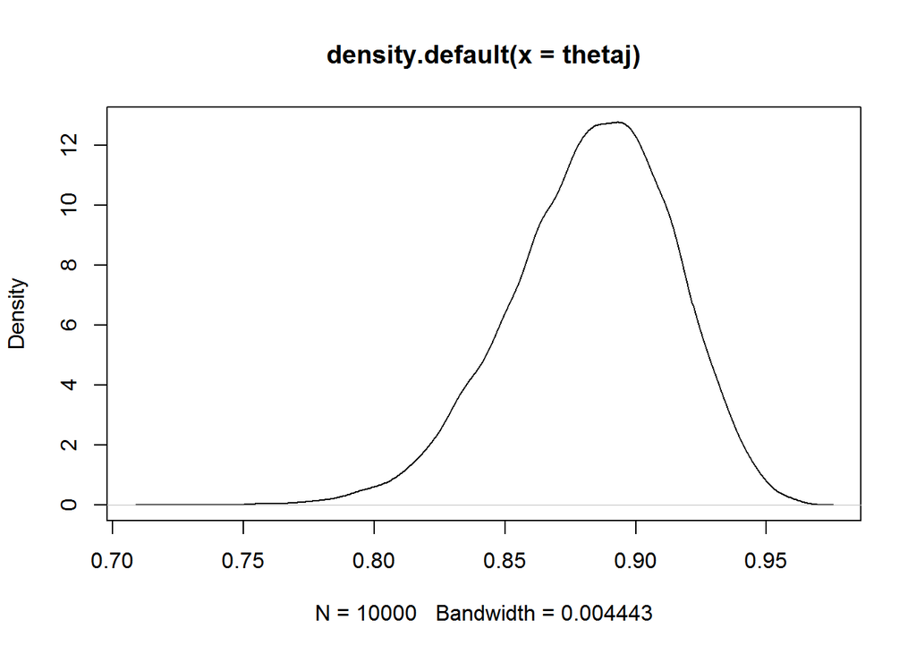

```r
plot(density(thetaj))
```

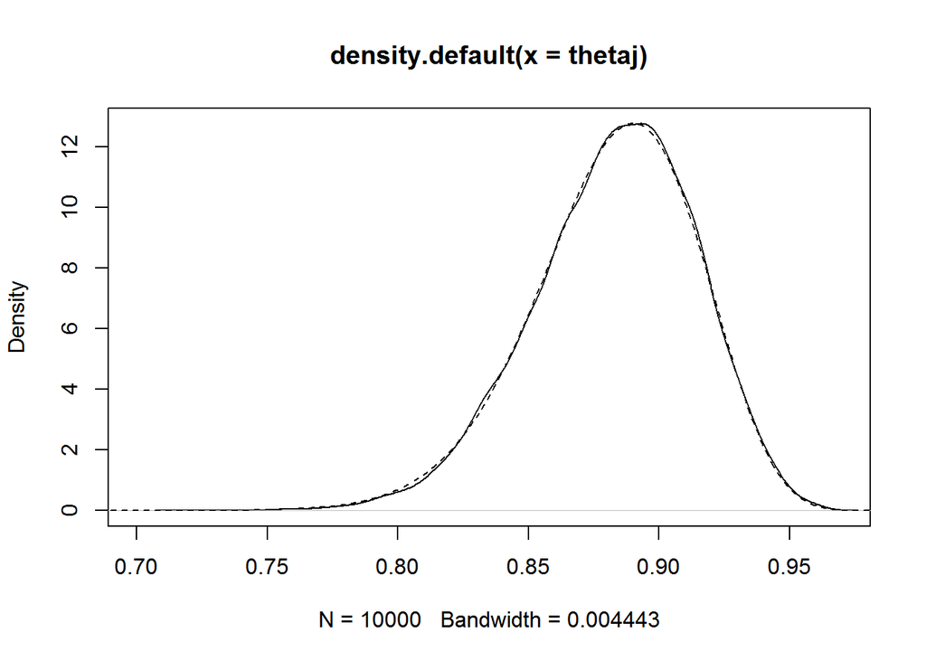

```r
plot(density(thetaj),xlim=c(0.7,0.97))
theta1 <- seq(0,1,.001)
lines(theta1,dbeta(theta1,90,12),type='l',lty=2)
```

#### (b) The same fan watches Shaquille O’Neal make only 40 out of 100 randomly chosen free throws from 20 games. Find the posterior density for his success proportion using a uniform prior and a 95% credible interval. Plot this density.

```r
thetao <- rbeta(100,41,61)
quantile(thetao,c(0.025,0.975))
```

```
##      2.5%     97.5%
## 0.3179467 0.4920925
```

gives $(0.3280602, 0.4925870)$ and we have 1-2 place accuracy.

```r
thetao <- rbeta(10000,41,61)
quantile(thetao,c(0.025,0.975))
```

```
##      2.5%     97.5%
## 0.3122498 0.4966129
```

gives $(0.3088187, 0.4962563)$ and we have 2 decimal places of accuracy.

```r
thetao <- rbeta(100000,41,61)
quantile(thetao,c(0.025,0.975))
```

```
##      2.5%     97.5%
## 0.3092561 0.4981993
```

gives $(0.3093610, 0.4979226)$ and 3 places of accuracy.

#### (c) Use what you know about these two players (if anything) to construct a Beta prior distribution for their success proportions at making free-throws and repeat the analysis in (a) and (b).

We refer you to Lab 2 Solutions: Suppose you suspect that Jordan’s percentage is somewhere between 0.75 and 0.95. Based on a prior mean of 0.85 and prior variance of $0.0025 = [(0.95-0.75)/4]^2$, we derived $a = 42.5 and b.= 7.5$.

Now, $Y_{J} \sim Bin(n =100, \theta_{J})$ and $\theta_{J} \sim Beta(42.5, 7.5)$, $p(\theta_{J} \mid Y_{J}) \propto p(Y_{J} \mid \theta_{J}) p(\theta_{J}) \propto \theta_{J}^{89}(1-\theta_{J} )11\theta_{J}^{41.5} (1-\theta_{J})^{6.5}=\theta_{J}^{130.5}(1-\theta_{J} )^{17.5}$

So, $\theta_{J} \mid Y_{j} \sim Beta( 131.5, 18.5)$.

The mode estimate is now $130.5/148 = 0.882$; posterior mean is $131.5/150 = 0.877$ and a 95% posterior CrI is $qbeta(0.025,131.5,18.5) = 0.820$ and $qbeta(0.975,131.5,18.5) = 0.924$.

Re-doing it with 10000 MC samples

```r
thetaj <- rbeta(10000,131.5,18.5)
quantile(thetaj,c(0.025,0.975))
```

```
##      2.5%     97.5%
## 0.8212413 0.9245079
```

which gives $(0.8200350, 0.9244421)$ We refer you to Lab 2 Solutions.

Now suppose that you suspect that O’Neal’s percentage is very close to 50% and very likely between 40 and 60%. We choose a prior mean of 0.5 with prior variance of $[(0.6-0.4)/4]^2 = 0.0025$.

This means that (from before):

$$\begin{aligned}
Y_{O} &\sim Bin(n =100, \theta_{O})\\
\theta_{O} &\sim Beta(49.5, 49.5) \\
p(\theta_{O} \mid y_{O} ) &\propto p( y_{O} \mid \theta_{O} ) p(\theta_{O} ) \\
&\propto \theta_{O}^{40} (1-\theta_{O})^{60} \theta_{O}^{48.5} (1-\theta_{O})^{48.5} \\
&= \theta_{O}^{88.5} (1- \theta_{O} )^{108.5}
\end{aligned}$$
So, $\theta_{O} \mid y_{O} \sim Beta(89.5, 109.5)$.

Re-doing it with 10000 MC samples

```r
thetao <- rbeta(10000,89.5,109.5)
quantile(thetao,c(0.025,0.975))
```

```
##      2.5%     97.5%
## 0.3808010 0.5176651
```

#### (d) What is the probability that Jordan’s free-throw percentage is above 90% from part (a)? from part (c)?

Instead of the Lab 2 Solutions, Question 3 (d), e.g.

```r
1-pbeta(0.9,90,12)
```

```
## [1] 0.3089547
```

given our vector $\theta$ we can approximate this by

```r
sum(thetaj>0.9)/10000 # (or: mean(theta>0.9))
```

```
## [1] 0.2074
```

#### (f) How can we compare the two success proportions? Is Jordan significantly better than O’Neal? What is the probability that Jordan is better than O’Neal? Use MC simulation to answer.

```r
length(thetaj[thetaj>thetao])   # (or: mean(thetaj>theta0))
```

```
## [1] 10000
```

#### (g) More interestingly, do this analysis for if O’Neal’s performance had been 80 out of 100. Provide an appropriate graph.

E.g.

```r
thetaj <- rbeta(1000000,90,12)
quantile(thetaj,c(0.025,0.975))
```

```
##      2.5%     97.5%
## 0.8133920 0.9370423
```

```r
thetao <- rbeta(1000000,81,21)
quantile(thetao,c(0.025,0.975))
```

```
##      2.5%     97.5%
## 0.7108399 0.8663849
```

I.e., substantial overlap (see graph too)

```r
mean(thetaj>thetao)
```

```
## [1] 0.959152
```

I.e., we still have ‘statistical significance’!

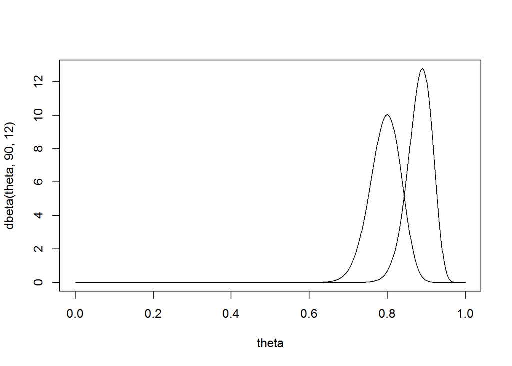

```r
theta <- seq(0,1,.001)
plot(theta,dbeta(theta,90,12),type='l')
lines(theta,dbeta(theta,81,21),type='l')
```

## Question 2

Consider again the placenta previa example, where y = no. of female births and $\theta = Pr(\text{female birth})$; we will take a sample of $n=1000$.

#### (a) After consultation with a specialist in Placenta previa, you place a $Beta(100,100)$ prior on . Show that this means that you (and the doctor) are more than 95% sure that $0.4 < \theta < 0.6$; but that you are undecided whether $\theta > 0.5$ OR $\theta < 0.5$.

If we have $\theta \sim Beta(100,100)$ we can easily answer questions such as $Pr(0.4 < \theta < 0.6) = pbeta(0.6,100,100) - pbeta(0.4,100,100) = 0.9956798 > 0.95$ And $Pr(\theta < 0.5) = pbeta(0.5,100,100) = 0.5$ thus verifying the two statements in the question. We could also do this via MC simulation:

```r
theta <- rbeta(10000,100,100)
length(theta[theta<0.5])/10000 #(or: mean...)
```

```
## [1] 0.5012
```

```r
(length(theta[theta<0.6])-length(theta[theta<0.4]))/10000
```

```
## [1] 0.9948
```

Which gives $0.5032$ and $0.9949$ which are correct to 2-3 decimal places.

#### (b) Is this a reasonable prior distribution?

Good question. It represents an expert’s opinion and puts almost all probability between 0.4 and 0.6. It is pictured below

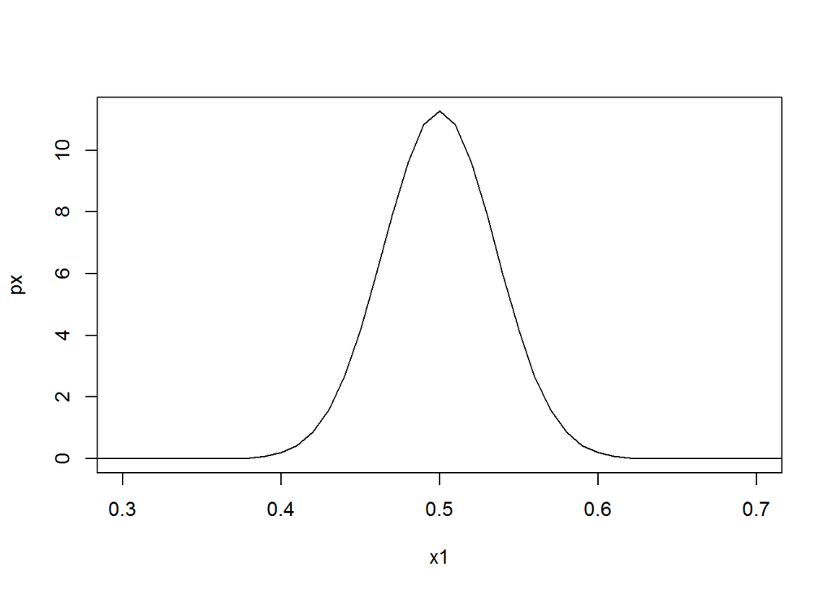

```r
x1 <- seq(0.01,1,0.01)
px <- dbeta(x1,100,100)
plot(x1,px,type = 'l', xlim=c(0.3,0.7))
```

#### (c) (Masters).

What does this prior imply about the possible observations, y, before we observe any data? Does this seem reasonable?

Recall the prior predictive density is a beta-binomial
$$p(y_1) = \frac{\Gamma(a+b)}{\Gamma(a)\Gamma(b)}\frac{\Gamma(n + 1)}{\Gamma(y_1 + 1)(n - y_1 + 1)}\frac{\Gamma(y_1 + a)\Gamma(n-y_1 + b)}{\Gamma(a+b+n)},\qquad y_1 = 0,\dots,
n$$
For $a=b=100$ we have

$$p(y_1) = \frac{\Gamma(200)}{\Gamma(100)\Gamma(100)}\frac{\Gamma(n + 1)}{\Gamma(y_1 + 1)(n - y_1 + 1)}\frac{\Gamma(y_1 + 100)\Gamma(n-y_1 + 100)}{\Gamma(100+100+n)},\qquad y_1 = 0,\dots,n$$

Let’s consider $n=10, 100, 1000, 10000$

```r
bb2 <- function(y,n,a,b) {
  g1 <- lgamma(a+b)-(lgamma(a)+lgamma(b))
  g2 <- lgamma(n+1)-(lgamma(y+1)+lgamma(n-y+1))
  g3 <- (lgamma(y+a)+lgamma(n-y+b))-lgamma(a+b+n)
  g <- g1+g2+g3
  exp(g)
}
```

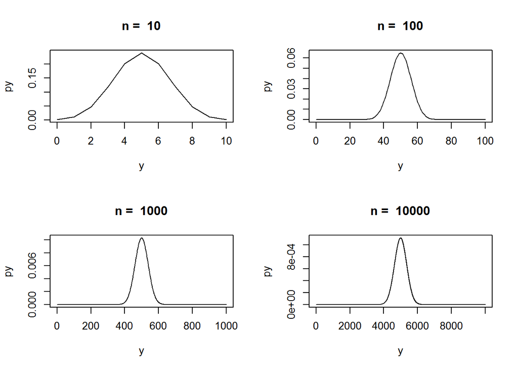

```r
n <- c(10,100,1000,10000)
a <- 100
b <- 100

par(mfrow=c(2,2))

for(i in 1:length(n)){
  y <- seq(0,n[i],1)
  py <- vector(mode='numeric', length = n[i])
  for(k in 1:length(y)){
    py[k] <- bb2(y[k],n[i],a,b)
  }
    plot(y, py, type = 'l', main = paste("n = ",n[i]))
}
```

The prior predictive puts most probability on y for y/n = 0.4 to 0.6 as would be expected from the Beta(100,100) prior which does the equivalent thing.

##### (d) The sample of $n=1000$ is taken and 511 males are born. Update your opinion about whether $\theta > 0.5$ OR $\theta < 0.5$.

$\theta \mid y=489, n=1000 \sim Beta(489+100, 511+100) = Beta(589, 611), Pr(\theta >0.5 \mid y=489, n=1000) = 1 - pbeta(0.5,589,611) = 0.263$. The density is plotted below with prior on top and posterior on bottom.

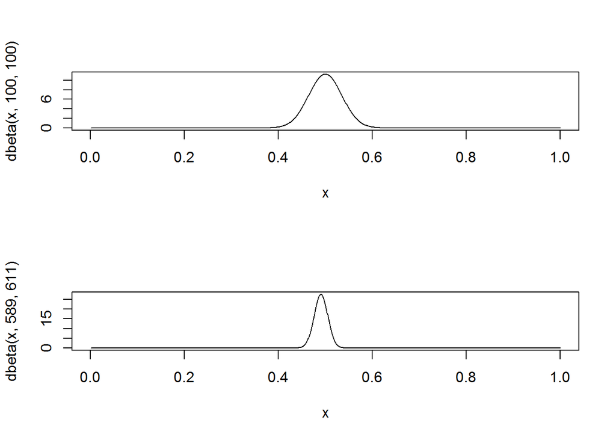

```r
par(mfrow=c(2,1))
x <- seq(0.001,1,0.001)
plot(x,dbeta(x,100,100),type='l')
plot(x,dbeta(x,589,611),type='l')
```

##### (e) Repeat (d) under a (i) Beta(1,1) prior (ii) Beta(a,b) prior where a and b are chosen so that the prior mean = 0.5 and prior standard deviation = 0.1

###### (i) Under a $Beta(1,1)$ prior,

$$\begin{aligned}
\theta \mid y=489, n=1000 &\sim Beta(489+1, 511+1) \\
&= Beta(490, 512) \\
Pr(\theta >0.5 \mid y=489, n=1000) &= 1 - pbeta(0.5,490,512) \\
&= 0.243
\end{aligned}$$

###### (ii)

$\frac{a}{a+b} = 0.5 \implies a = b$ and $\frac{a + b}{(a + b)^2 (a + b + 1)}=\frac{a^2}{4a^2(2a+1)}=\frac{1}{8a+4}=0.1^2\implies a = b = 12$ Under a $Beta(12,12)$ prior prior, $\theta \mid y=489, n=1000 \sim Beta(489+12, 511+12) = Beta(501, 523), Pr(\theta >0.5 \mid y=489, n=1000) = 1 - pbeta(0.5,501,523) = 0.246$

#### (f) How sensitive are the results to choice of prior?

The results seem not sensitive to prior choice, especially for priors with mean close to 0.5.

## Question 3

Adapted from BDA, Section 1.12, question 1. Let $y \sim N (\theta ,4)$ , so that $y$ is Normally distributed with unknown mean $\theta$ and known variance $4$. Let the prior distribution on the mean $\theta$ be

```r
tbl = matrix(c(1,2,0.5,0.5), 2, 2)
colnames(tbl) = c(1, 2)
row.labels = c("\U03B8","Pr(\U03B8)")
rownames(tbl) = row.labels
kable(tbl,escape = FALSE)
```

[output not shown]

Thus $\theta$ can only take the values $1$ or $2$, both with equal probability.

#### (a) A single sample of $y=1$ is observed. Update the discrete probability distribution for $\theta$ using Bayes’ rule. i.e. find $p(\theta \mid y = 1)$.

$$p(\theta \mid y = 1) \propto p( y = 1\mid \theta ) p(\theta ) = (8\pi )^{-0.5}exp\left(-\frac{1}{8}(y-\theta )^2\right)p(\theta ) \\
=dnorm(1,\theta,\sqrt4)/2$$

for $\theta = 1$ and then $\theta = 2$ So the posterior is $Pr ( \theta =1 \mid y=1) = 0.531, Pr (\theta =2 \mid y=1) = 0.469$.

#### (b) A single observation of $y=1.5$ is observed. Update the prior, ignoring the data point in part (a).

$p(\theta \mid y = 1.5) \propto p(y = 1.5 \mid \theta)p(\theta) = (8\pi)^{-0.5}exp\left(-\frac{1}{8}(1.5-\theta)^2\right)p(\theta)$

| theta | Prior | Likelihood | Product | Posterior |
| --- | --- | --- | --- | --- |
| 1 | 0.5 | 0.1933 | 0.09665 | 0.5 |
| 2 | 0.5 | 0.1933 | 0.09665 | 0.5 |
|  |  | Sum | 0.1933 |  |

$=dnorm(1.5,\theta,sqrt(4))*0.5$ for $\theta = 1$ and then $\theta = 2$  
So the posterior is $Pr (\theta =1 \mid y=1.5) = 0.5,Pr ( \theta =2 \mid y=1.5) = 0.5$.

Clearly this point doesn’t give us ANY extra info about $\theta$ since it is exactly half way between 1 and 2!

#### (c) Update the prior using Bayes’ rule after observing both sample points in (a) and (b). That is we have a sample of size $2, y1 = 1; y2 = 1.5.$

$$p(\theta \mid y = 1,1.5) \propto p( y = (1,1.5) \mid \theta ) p(\theta ) = (8\pi)^{-1}exp\left(-\frac{1}{8}\left[(1 - \theta)^2 +(1.5 - \theta)^2\right]\right)p(\theta )$$

| theta | Prior | Likelihood | Product | Posterior |
| --- | --- | --- | --- | --- |
| 1 | 0.5 | 0.0386 | 0.0193 | 0.531 |
| 2 | 0.5 | 0.034 | 0.017 | 0.469 |
|  |  | Sum | 0.0363 |  |

$=dnorm(1,\theta,sqrt(4))* dnorm(1.5,\theta,sqrt(4))*0.5$ for $\theta = 1$ and then $\theta = 2$

So the posterior is $Pr ( \theta =1 \mid y=1) = 0.531,Pr ( \theta =2 \mid y=1) = 0.469$. This is the same as in (a). The point 1.5 is exactly between 1 and 2 and gives NO information either way about $\theta =1$ or $2$, as shown in (b).

#### (d) Use probability rules to find the marginal likelihood p(y), i.e. the likelihood unconditional on $\theta$. Plot this likelihood over a sensible grid of points.

Use probability rules to find the marginal likelihood p(y), i.e. the likelihood unconditional on $\theta$. Plot this likelihood over a sensible grid of points.
$$p( y) = \sum p(y \mid \theta ) p(\theta ) = \sum(8\pi)^{-0.5}exp\left(-\frac{1}{8}(y - \theta)^2 \right)p(\theta ) \\
=0.5(8\pi)^{-0.5}\left[exp\left(-\frac{1}{8}(y - 1)^2\right) +exp\left(-\frac{1}{8}(y-2)^2\right)\right]$$
e.g.

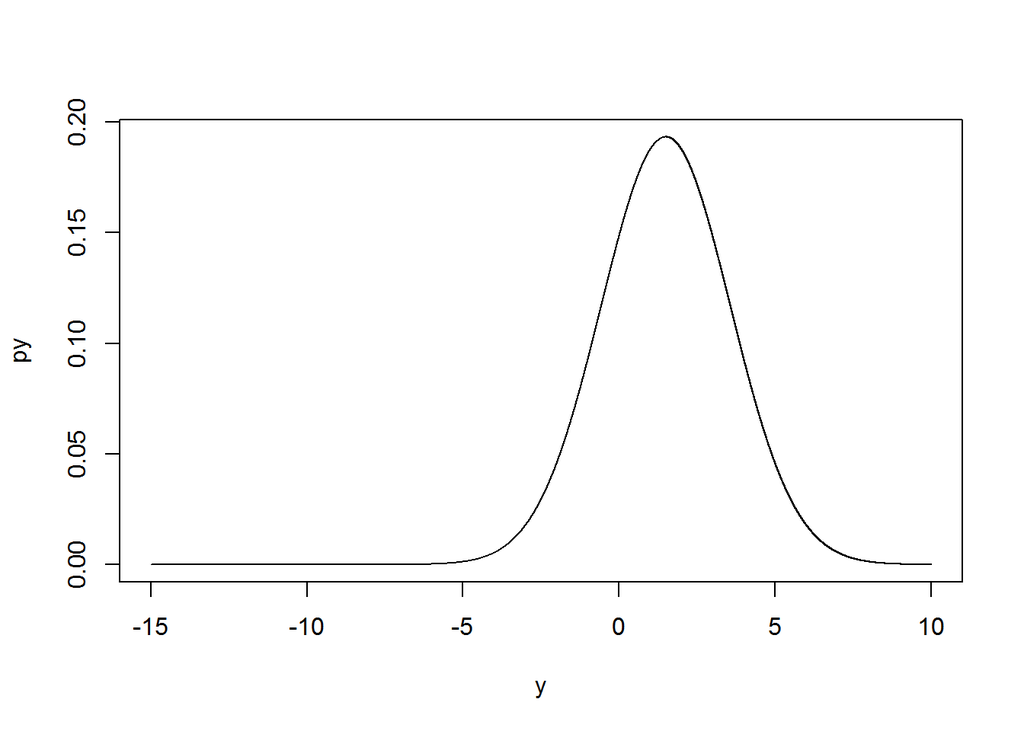

```r
y <- seq(-15,10,.001)
py <- (dnorm(y,1,sqrt(4))+dnorm(y,2,sqrt(4)))*0.5
plot(y,py,type='l')
```

#### (e) What is the mean and variance of $p(y)$?

$$\begin{aligned}
E(Y) &= E[E(Y \mid \theta )] \\
&= E(\theta ) \\
&= 1* 0.5 + 2 * 0.5 \\
&= 1.5 \\
Var(Y) &= Var[E(Y \mid \theta )] + E[Var(Y \mid \theta )] \\ &= Var(\theta ) + E[4] \\
&= E(\theta^2 ) - E(\theta)^2 + 4 \\
&= 12 * 0.5 + 22 * 0.5 - 1.5^2 + 4 \\
&= 4.25
\end{aligned}$$

You could use integration here but it gets messy!

#### (f) Can you simulate from $p(y)$? If so, simulate a sample of size $10000$ and check the sample mean and variance are close to the theoretical values in (b). Estimate a 95% CrI for y based on the sample.

The R code is

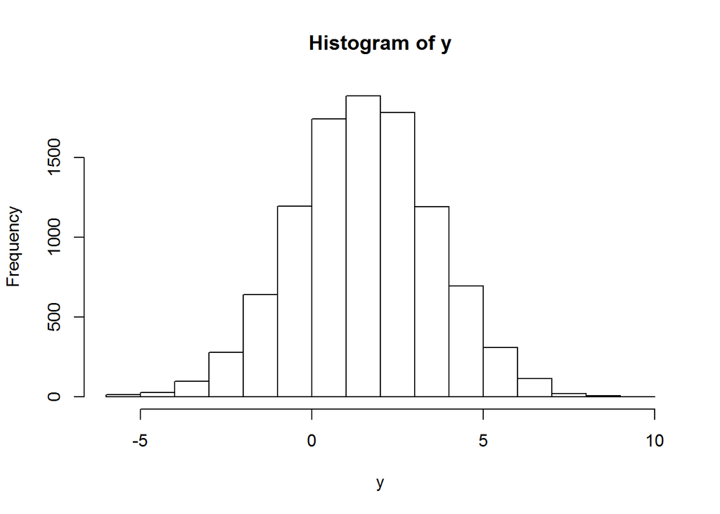

```r
y <- 0
for(k in 1:10000) {
  if(runif(1,0,1)>0.5) {
    y[k]=rnorm(1,2,sqrt(4))
    } else {
      y[k] <- rnorm(1,1,sqrt(4))
    }
}
hist(y)
```

The mean and variance of my sample is $1.51$ and $4.24$ respectively as expected. A 95% CrI for y is $quantile(y,c(0.025,0.975))$ = (-2.5109267, 5.4938846).

This is an example of a mixture of 2 Normal distributions.